# Solutions — Session 4: Cleaning a Messy Survey Export

M731 · Full worked walkthrough (companion to session-04.qmd)

Author

Shay Abbasi

## Purpose

Full worked version of the Session 4 in-lab exercise: cleaning column names, reverse-coding, straight-line detection, and composite-score construction on a deliberately messy survey export.

**Dataset provenance.** The original slide deck referenced Kaggle’s [“Young People Survey”](https://www.kaggle.com/datasets/miroslavsabo/young-people-survey) (Sabo, 2016). That dataset is third-party and not ours to redistribute in a course repo, so `kaggle_survey_raw.csv` here is an **instructor-simulated stand-in** with the same messy structure (inconsistent column names, mixed NA encodings, a reverse-worded item pair, and two multi-item batteries: an 8-item `Music` battery and a 6-item `Movies_` battery, plus `loneliness_1`/`loneliness_2`). If your own teaching context has access to the real dataset, swap it in — the cleaning code below is unaffected either way.

## Setup

```r
library(tidyverse)
library(janitor)

raw <- read_csv("data/kaggle_survey_raw.csv")
dim(raw)
```

```
[1] 1010   19
```

## Step 1 — Clean column names

```r
raw <- raw |> clean_names()
names(raw)
```

```
 [1] "age"          "gender"       "village_town" "music_1"      "music_2"
 [6] "music_3"      "music_4"      "music_5"      "music_6"      "music_7"
[11] "music_8"      "movies_1"     "movies_2"     "movies_3"     "movies_4"
[16] "movies_5"     "movies_6"     "loneliness_1" "loneliness_2"
```

**Interpretation.** `clean_names()` converts `"Age "`, `"Village - town"`, `"Music 1"` etc. into consistent `snake_case` (`age`, `village_town`, `music_1`…). This single step eliminates most quoting headaches for the rest of the pipeline.

## Step 2 — Reverse-code the reversed item

`loneliness_2` was deliberately generated as the reverse-worded partner of `loneliness_1` (see `data-raw/generate_datasets.R`).

```r
raw <- raw |>
  mutate(loneliness_2_r = 6 - loneliness_2)

cor(raw$loneliness_1, raw$loneliness_2, use = "complete.obs")
```

```
[1] -0.4516099
```

```r
cor(raw$loneliness_1, raw$loneliness_2_r, use = "complete.obs")
```

```
[1] 0.4516099
```

**Interpretation.** Before reversing, `loneliness_1` and `loneliness_2` correlate negatively (as expected for a reverse-worded pair). After reversing `loneliness_2`, the correlation flips positive — confirmation the reversal was applied correctly. **Always check this correlation before and after** — it’s the fastest way to catch a reverse-coding bug.

## Step 3 — Missing-value audit

```r
raw |>
  summarise(across(everything(), ~ sum(is.na(.)))) |>
  pivot_longer(everything(), names_to = "col", values_to = "n_missing") |>
  arrange(desc(n_missing)) |>
  head(10)
```

```
# A tibble: 10 × 2
   col      n_missing
   <chr>        <int>
 1 gender          61
 2 music_5         61
 3 music_8         61
 4 movies_1        61
 5 movies_2        61
 6 movies_3        61
 7 movies_4        61
 8 movies_5        61
 9 movies_6        61
10 music_1         60
```

**Interpretation.** Missingness is scattered at roughly 3-6% per column by design — realistic for a real export, not catastrophic. Decide per column: for the music/movies batteries we’ll keep `NA` and use `na.rm = TRUE` in composite scoring below; for `age` (a screening variable) a stricter case-wise drop might be warranted for downstream models.

## Step 4 — Straight-line detection

```r
music_items <- raw |> select(starts_with("music_"))

raw$music_sd <- apply(music_items, 1, sd, na.rm = TRUE)

raw |>
  arrange(music_sd) |>
  select(music_sd, starts_with("music_")) |>
  head(10)
```

```
# A tibble: 10 × 9
   music_sd music_1 music_2 music_3 music_4 music_5 music_6 music_7 music_8
      <dbl>   <dbl>   <dbl>   <dbl>   <dbl>   <dbl>   <dbl>   <dbl>   <dbl>
 1        0       3       3       3       3       3       3       3       3
 2        0       3       3       3       3       3       3       3       3
 3        0       3       3       3       3       3       3       3       3
 4        0       3       3       3       3       3       3       3       3
 5        0       3       3       3       3       3       3       3       3
 6        0       3       3       3       3       3       3       3       3
 7        0       3       3       3       3       3       3       3       3
 8        0       3       3       3       3       3       3       3       3
 9        0       3       3       3       3       3       3       3       3
10        0       3       3       3       3       3       3       3       3
```

**Interpretation.** Rows with `music_sd` at or near 0 answered every item in the battery identically — the classic straight-lining signature. `data-raw/generate_datasets.R` deliberately planted 25 such rows so this diagnostic has something real to catch; in your own data, flag rows below roughly SD < 0.3 on a 5-point battery for review or exclusion.

## Step 5 — Composite score + distribution

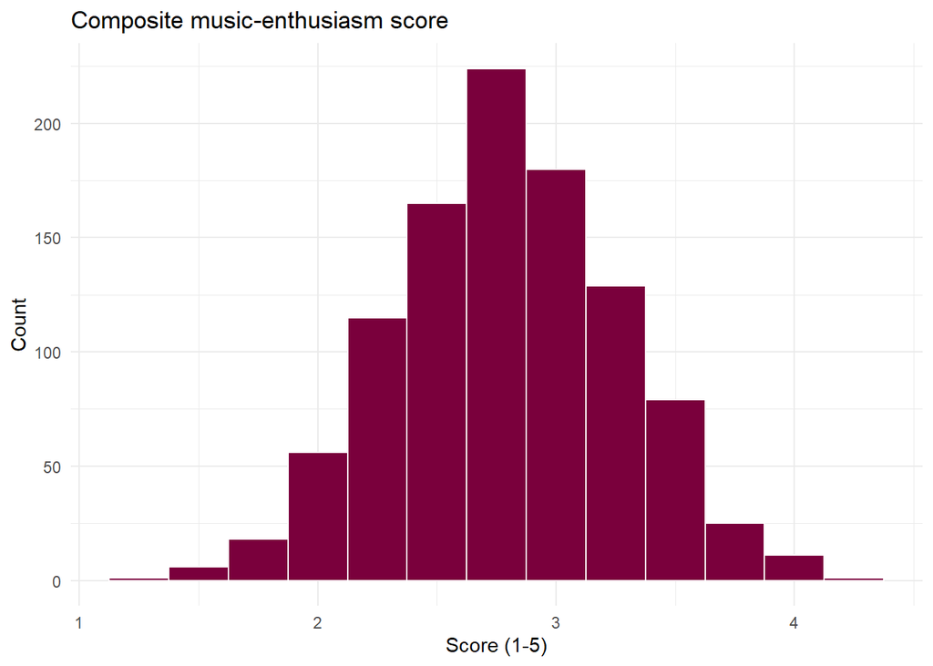

Figure 1: Distribution of the composite music-enthusiasm score

```r
raw <- raw |>
  mutate(music_score = rowMeans(select(raw, starts_with("music_")), na.rm = TRUE))

raw |>
  ggplot(aes(x = music_score)) +
  geom_histogram(binwidth = 0.25, fill = "#7A003C", colour = "white") +
  labs(title = "Composite music-enthusiasm score", x = "Score (1-5)", y = "Count") +
  theme_minimal()
```

## Take-away for students

Every messy-data pipeline follows the same order: **clean names → check/reverse-code → audit missingness → detect quality problems → build composites → visualise before you trust anything.** Skipping a step (especially the reverse-code check) is the single most common source of “why is my alpha negative” panic in Week 8.